# Optimal Treatment Analysis

## Outcome Variable

**Outcome Variable:** ever_stunted

## Predictor Variables

**Intervention Variable:** brthmon

**Adjustment Set:**

unadjusted

## Stratifying Variables

The analysis was stratified on these variable(s):

- agecat
- studyid
- country

## Data Summary

| agecat | studyid | country | brthmon | ever_stunted | n_cell | n |
| --- | --- | --- | --- | --- | --- | --- |
| 0-24 months | ki0047075b-MAL-ED | BANGLADESH | 1 | 0 | 8 | 265 |
| 0-24 months | ki0047075b-MAL-ED | BANGLADESH | 1 | 1 | 13 | 265 |
| 0-24 months | ki0047075b-MAL-ED | BANGLADESH | 2 | 0 | 7 | 265 |
| 0-24 months | ki0047075b-MAL-ED | BANGLADESH | 2 | 1 | 18 | 265 |
| 0-24 months | ki0047075b-MAL-ED | BANGLADESH | 3 | 0 | 8 | 265 |
| 0-24 months | ki0047075b-MAL-ED | BANGLADESH | 3 | 1 | 17 | 265 |
| 0-24 months | ki0047075b-MAL-ED | BANGLADESH | 4 | 0 | 12 | 265 |
| 0-24 months | ki0047075b-MAL-ED | BANGLADESH | 4 | 1 | 10 | 265 |
| 0-24 months | ki0047075b-MAL-ED | BANGLADESH | 5 | 0 | 5 | 265 |
| 0-24 months | ki0047075b-MAL-ED | BANGLADESH | 5 | 1 | 17 | 265 |
| 0-24 months | ki0047075b-MAL-ED | BANGLADESH | 6 | 0 | 5 | 265 |
| 0-24 months | ki0047075b-MAL-ED | BANGLADESH | 6 | 1 | 6 | 265 |
| 0-24 months | ki0047075b-MAL-ED | BANGLADESH | 7 | 0 | 7 | 265 |
| 0-24 months | ki0047075b-MAL-ED | BANGLADESH | 7 | 1 | 13 | 265 |
| 0-24 months | ki0047075b-MAL-ED | BANGLADESH | 8 | 0 | 10 | 265 |
| 0-24 months | ki0047075b-MAL-ED | BANGLADESH | 8 | 1 | 16 | 265 |
| 0-24 months | ki0047075b-MAL-ED | BANGLADESH | 9 | 0 | 10 | 265 |
| 0-24 months | ki0047075b-MAL-ED | BANGLADESH | 9 | 1 | 13 | 265 |
| 0-24 months | ki0047075b-MAL-ED | BANGLADESH | 10 | 0 | 13 | 265 |
| 0-24 months | ki0047075b-MAL-ED | BANGLADESH | 10 | 1 | 12 | 265 |
| 0-24 months | ki0047075b-MAL-ED | BANGLADESH | 11 | 0 | 8 | 265 |
| 0-24 months | ki0047075b-MAL-ED | BANGLADESH | 11 | 1 | 9 | 265 |
| 0-24 months | ki0047075b-MAL-ED | BANGLADESH | 12 | 0 | 11 | 265 |
| 0-24 months | ki0047075b-MAL-ED | BANGLADESH | 12 | 1 | 17 | 265 |
| 0-24 months | ki0047075b-MAL-ED | BRAZIL | 1 | 0 | 12 | 233 |
| 0-24 months | ki0047075b-MAL-ED | BRAZIL | 1 | 1 | 3 | 233 |
| 0-24 months | ki0047075b-MAL-ED | BRAZIL | 2 | 0 | 18 | 233 |
| 0-24 months | ki0047075b-MAL-ED | BRAZIL | 2 | 1 | 7 | 233 |
| 0-24 months | ki0047075b-MAL-ED | BRAZIL | 3 | 0 | 16 | 233 |
| 0-24 months | ki0047075b-MAL-ED | BRAZIL | 3 | 1 | 4 | 233 |

[output cut: 2034 more lines]

The following strata were considered:

- agecat: 0-24 months, studyid: ki0047075b-MAL-ED, country: BANGLADESH
- agecat: 0-24 months, studyid: ki0047075b-MAL-ED, country: BRAZIL
- agecat: 0-24 months, studyid: ki0047075b-MAL-ED, country: INDIA
- agecat: 0-24 months, studyid: ki0047075b-MAL-ED, country: NEPAL
- agecat: 0-24 months, studyid: ki0047075b-MAL-ED, country: PERU
- agecat: 0-24 months, studyid: ki0047075b-MAL-ED, country: SOUTH AFRICA
- agecat: 0-24 months, studyid: ki0047075b-MAL-ED, country: TANZANIA, UNITED REPUBLIC OF
- agecat: 0-24 months, studyid: ki1000108-CMC-V-BCS-2002, country: INDIA
- agecat: 0-24 months, studyid: ki1000108-IRC, country: INDIA
- agecat: 0-24 months, studyid: ki1000109-EE, country: PAKISTAN
- agecat: 0-24 months, studyid: ki1000109-ResPak, country: PAKISTAN
- agecat: 0-24 months, studyid: ki1000304b-SAS-CompFeed, country: INDIA
- agecat: 0-24 months, studyid: ki1000304b-SAS-FoodSuppl, country: INDIA
- agecat: 0-24 months, studyid: ki1017093-NIH-Birth, country: BANGLADESH
- agecat: 0-24 months, studyid: ki1066203-TanzaniaChild2, country: TANZANIA, UNITED REPUBLIC OF
- agecat: 0-24 months, studyid: ki1101329-Keneba, country: GAMBIA
- agecat: 0-24 months, studyid: ki1112895-Guatemala BSC, country: GUATEMALA
- agecat: 0-24 months, studyid: ki1112895-iLiNS-Zinc, country: BURKINA FASO
- agecat: 0-24 months, studyid: ki1113344-GMS-Nepal, country: NEPAL
- agecat: 0-24 months, studyid: ki1114097-CMIN, country: BANGLADESH
- agecat: 0-24 months, studyid: ki1114097-CMIN, country: BRAZIL
- agecat: 0-24 months, studyid: ki1114097-CMIN, country: GUINEA-BISSAU
- agecat: 0-24 months, studyid: ki1114097-CMIN, country: PERU
- agecat: 0-24 months, studyid: ki1114097-CONTENT, country: PERU
- agecat: 0-24 months, studyid: ki1119695-PROBIT, country: BELARUS
- agecat: 0-24 months, studyid: ki1126311-ZVITAMBO, country: ZIMBABWE
- agecat: 0-24 months, studyid: ki1148112-LCNI-5, country: MALAWI
- agecat: 0-24 months, studyid: kiGH5241-JiVitA-3, country: BANGLADESH
- agecat: 0-24 months, studyid: kiGH5241-JiVitA-4, country: BANGLADESH
- agecat: 0-6 months, studyid: ki0047075b-MAL-ED, country: BANGLADESH
- agecat: 0-6 months, studyid: ki0047075b-MAL-ED, country: BRAZIL
- agecat: 0-6 months, studyid: ki0047075b-MAL-ED, country: INDIA
- agecat: 0-6 months, studyid: ki0047075b-MAL-ED, country: NEPAL
- agecat: 0-6 months, studyid: ki0047075b-MAL-ED, country: PERU
- agecat: 0-6 months, studyid: ki0047075b-MAL-ED, country: SOUTH AFRICA
- agecat: 0-6 months, studyid: ki0047075b-MAL-ED, country: TANZANIA, UNITED REPUBLIC OF
- agecat: 0-6 months, studyid: ki1000108-CMC-V-BCS-2002, country: INDIA
- agecat: 0-6 months, studyid: ki1000108-IRC, country: INDIA
- agecat: 0-6 months, studyid: ki1000109-EE, country: PAKISTAN
- agecat: 0-6 months, studyid: ki1000109-ResPak, country: PAKISTAN
- agecat: 0-6 months, studyid: ki1000304b-SAS-CompFeed, country: INDIA
- agecat: 0-6 months, studyid: ki1000304b-SAS-FoodSuppl, country: INDIA
- agecat: 0-6 months, studyid: ki1017093-NIH-Birth, country: BANGLADESH
- agecat: 0-6 months, studyid: ki1066203-TanzaniaChild2, country: TANZANIA, UNITED REPUBLIC OF
- agecat: 0-6 months, studyid: ki1101329-Keneba, country: GAMBIA
- agecat: 0-6 months, studyid: ki1112895-Guatemala BSC, country: GUATEMALA
- agecat: 0-6 months, studyid: ki1113344-GMS-Nepal, country: NEPAL
- agecat: 0-6 months, studyid: ki1114097-CMIN, country: BANGLADESH
- agecat: 0-6 months, studyid: ki1114097-CMIN, country: BRAZIL
- agecat: 0-6 months, studyid: ki1114097-CMIN, country: GUINEA-BISSAU
- agecat: 0-6 months, studyid: ki1114097-CMIN, country: PERU
- agecat: 0-6 months, studyid: ki1114097-CONTENT, country: PERU
- agecat: 0-6 months, studyid: ki1119695-PROBIT, country: BELARUS
- agecat: 0-6 months, studyid: ki1126311-ZVITAMBO, country: ZIMBABWE
- agecat: 0-6 months, studyid: ki1148112-LCNI-5, country: MALAWI
- agecat: 0-6 months, studyid: kiGH5241-JiVitA-3, country: BANGLADESH
- agecat: 0-6 months, studyid: kiGH5241-JiVitA-4, country: BANGLADESH
- agecat: 6-24 months, studyid: ki0047075b-MAL-ED, country: BANGLADESH
- agecat: 6-24 months, studyid: ki0047075b-MAL-ED, country: BRAZIL
- agecat: 6-24 months, studyid: ki0047075b-MAL-ED, country: INDIA
- agecat: 6-24 months, studyid: ki0047075b-MAL-ED, country: NEPAL
- agecat: 6-24 months, studyid: ki0047075b-MAL-ED, country: PERU
- agecat: 6-24 months, studyid: ki0047075b-MAL-ED, country: SOUTH AFRICA
- agecat: 6-24 months, studyid: ki0047075b-MAL-ED, country: TANZANIA, UNITED REPUBLIC OF
- agecat: 6-24 months, studyid: ki1000108-CMC-V-BCS-2002, country: INDIA
- agecat: 6-24 months, studyid: ki1000108-IRC, country: INDIA
- agecat: 6-24 months, studyid: ki1000109-EE, country: PAKISTAN
- agecat: 6-24 months, studyid: ki1000109-ResPak, country: PAKISTAN
- agecat: 6-24 months, studyid: ki1000304b-SAS-CompFeed, country: INDIA
- agecat: 6-24 months, studyid: ki1000304b-SAS-FoodSuppl, country: INDIA
- agecat: 6-24 months, studyid: ki1017093-NIH-Birth, country: BANGLADESH
- agecat: 6-24 months, studyid: ki1066203-TanzaniaChild2, country: TANZANIA, UNITED REPUBLIC OF
- agecat: 6-24 months, studyid: ki1101329-Keneba, country: GAMBIA
- agecat: 6-24 months, studyid: ki1112895-Guatemala BSC, country: GUATEMALA
- agecat: 6-24 months, studyid: ki1112895-iLiNS-Zinc, country: BURKINA FASO
- agecat: 6-24 months, studyid: ki1113344-GMS-Nepal, country: NEPAL
- agecat: 6-24 months, studyid: ki1114097-CMIN, country: BANGLADESH
- agecat: 6-24 months, studyid: ki1114097-CMIN, country: BRAZIL
- agecat: 6-24 months, studyid: ki1114097-CMIN, country: GUINEA-BISSAU
- agecat: 6-24 months, studyid: ki1114097-CMIN, country: PERU
- agecat: 6-24 months, studyid: ki1114097-CONTENT, country: PERU
- agecat: 6-24 months, studyid: ki1119695-PROBIT, country: BELARUS
- agecat: 6-24 months, studyid: ki1126311-ZVITAMBO, country: ZIMBABWE
- agecat: 6-24 months, studyid: ki1148112-LCNI-5, country: MALAWI
- agecat: 6-24 months, studyid: kiGH5241-JiVitA-3, country: BANGLADESH
- agecat: 6-24 months, studyid: kiGH5241-JiVitA-4, country: BANGLADESH

### Dropped Strata

Some strata were dropped due to rare outcomes:

- agecat: 0-24 months, studyid: ki0047075b-MAL-ED, country: BRAZIL
- agecat: 0-24 months, studyid: ki0047075b-MAL-ED, country: INDIA
- agecat: 0-24 months, studyid: ki0047075b-MAL-ED, country: NEPAL
- agecat: 0-24 months, studyid: ki0047075b-MAL-ED, country: SOUTH AFRICA
- agecat: 0-24 months, studyid: ki0047075b-MAL-ED, country: TANZANIA, UNITED REPUBLIC OF
- agecat: 0-24 months, studyid: ki1000108-CMC-V-BCS-2002, country: INDIA
- agecat: 0-24 months, studyid: ki1000108-IRC, country: INDIA
- agecat: 0-24 months, studyid: ki1000109-EE, country: PAKISTAN
- agecat: 0-24 months, studyid: ki1000109-ResPak, country: PAKISTAN
- agecat: 0-24 months, studyid: ki1000304b-SAS-FoodSuppl, country: INDIA
- agecat: 0-24 months, studyid: ki1112895-Guatemala BSC, country: GUATEMALA
- agecat: 0-24 months, studyid: ki1113344-GMS-Nepal, country: NEPAL
- agecat: 0-24 months, studyid: ki1114097-CMIN, country: BANGLADESH
- agecat: 0-24 months, studyid: ki1114097-CMIN, country: BRAZIL
- agecat: 0-24 months, studyid: ki1114097-CONTENT, country: PERU
- agecat: 0-24 months, studyid: kiGH5241-JiVitA-4, country: BANGLADESH
- agecat: 0-6 months, studyid: ki0047075b-MAL-ED, country: BANGLADESH
- agecat: 0-6 months, studyid: ki0047075b-MAL-ED, country: BRAZIL
- agecat: 0-6 months, studyid: ki0047075b-MAL-ED, country: INDIA
- agecat: 0-6 months, studyid: ki0047075b-MAL-ED, country: NEPAL
- agecat: 0-6 months, studyid: ki0047075b-MAL-ED, country: PERU
- agecat: 0-6 months, studyid: ki0047075b-MAL-ED, country: SOUTH AFRICA
- agecat: 0-6 months, studyid: ki0047075b-MAL-ED, country: TANZANIA, UNITED REPUBLIC OF
- agecat: 0-6 months, studyid: ki1000109-EE, country: PAKISTAN
- agecat: 0-6 months, studyid: ki1000109-ResPak, country: PAKISTAN
- agecat: 0-6 months, studyid: ki1000304b-SAS-FoodSuppl, country: INDIA
- agecat: 0-6 months, studyid: ki1112895-Guatemala BSC, country: GUATEMALA
- agecat: 0-6 months, studyid: ki1113344-GMS-Nepal, country: NEPAL
- agecat: 0-6 months, studyid: ki1114097-CMIN, country: BANGLADESH
- agecat: 0-6 months, studyid: ki1114097-CMIN, country: BRAZIL
- agecat: 0-6 months, studyid: ki1114097-CMIN, country: GUINEA-BISSAU
- agecat: 0-6 months, studyid: ki1114097-CMIN, country: PERU
- agecat: 0-6 months, studyid: ki1114097-CONTENT, country: PERU
- agecat: 0-6 months, studyid: ki1148112-LCNI-5, country: MALAWI
- agecat: 0-6 months, studyid: kiGH5241-JiVitA-4, country: BANGLADESH
- agecat: 6-24 months, studyid: ki0047075b-MAL-ED, country: BANGLADESH
- agecat: 6-24 months, studyid: ki0047075b-MAL-ED, country: BRAZIL
- agecat: 6-24 months, studyid: ki0047075b-MAL-ED, country: INDIA
- agecat: 6-24 months, studyid: ki0047075b-MAL-ED, country: NEPAL
- agecat: 6-24 months, studyid: ki0047075b-MAL-ED, country: PERU
- agecat: 6-24 months, studyid: ki0047075b-MAL-ED, country: SOUTH AFRICA
- agecat: 6-24 months, studyid: ki0047075b-MAL-ED, country: TANZANIA, UNITED REPUBLIC OF
- agecat: 6-24 months, studyid: ki1000108-CMC-V-BCS-2002, country: INDIA
- agecat: 6-24 months, studyid: ki1000108-IRC, country: INDIA
- agecat: 6-24 months, studyid: ki1000109-EE, country: PAKISTAN
- agecat: 6-24 months, studyid: ki1000109-ResPak, country: PAKISTAN
- agecat: 6-24 months, studyid: ki1000304b-SAS-FoodSuppl, country: INDIA
- agecat: 6-24 months, studyid: ki1112895-Guatemala BSC, country: GUATEMALA
- agecat: 6-24 months, studyid: ki1113344-GMS-Nepal, country: NEPAL
- agecat: 6-24 months, studyid: ki1114097-CMIN, country: BANGLADESH
- agecat: 6-24 months, studyid: ki1114097-CMIN, country: BRAZIL
- agecat: 6-24 months, studyid: ki1114097-CONTENT, country: PERU
- agecat: 6-24 months, studyid: kiGH5241-JiVitA-4, country: BANGLADESH

## Methods Detail

We’re interested in the causal parameters $E[Y_a]$ for all values of $a \in \mathcal{A}$. These parameters represent the mean outcome if, possibly contrary to fact, we intervened to set all units to have $A=a$. Under the randomization and positivity assumptions, these are identified by the statistical parameters $\psi_a=E_W[E_{Y|A,W}(Y|A=a,W)]$. In addition, we’re interested in the mean of $Y$, $E[Y]$ under no intervention (the observed mean). We will estimate these parameters by using SuperLearner to fit the relevant likelihood factors – $E_{Y|A,W}(Y|A=a,W)$ and $p(A=a|W)$, and then updating our likelihood fit using a joint TMLE.

For unadjusted analyses ($W=\{\}$), initial likelihoods were estimated using Lrnr_glm to estimate the simple $E(Y|A)$ and Lrnr_mean to estimate $p(A)$. For adjusted analyses, a small library containing Lrnr_glmnet, Lrnr_xgboost, and Lrnr_mean was used.

Having estimated these parameters, we will then use the delta method to estimate relative risks and attributable risks relative to a prespecified baseline level of $A$.

# Results Detail

## Results Plots

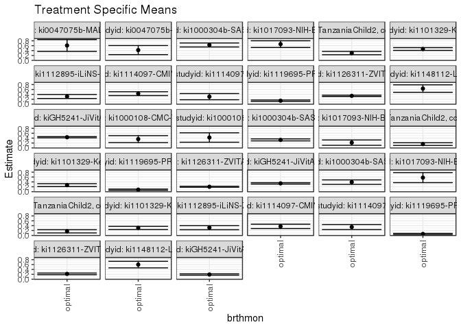

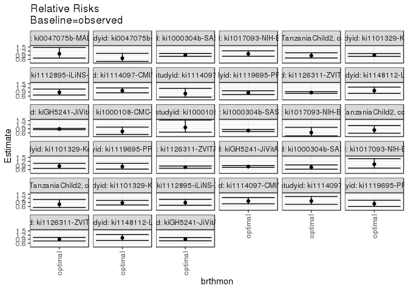

## Results Table

### Parameter: TSM

| agecat | studyid | country | intervention_level | baseline_level | estimate | ci_lower | ci_upper |
| --- | --- | --- | --- | --- | --- | --- | --- |
| 0-24 months | ki0047075b-MAL-ED | BANGLADESH | optimal | NA | 0.6083784 | 0.3667468 | 0.8500100 |
| 0-24 months | ki0047075b-MAL-ED | PERU | optimal | NA | 0.4205489 | 0.2348462 | 0.6062515 |
| 0-24 months | ki1000304b-SAS-CompFeed | INDIA | optimal | NA | 0.6297783 | 0.5477349 | 0.7118218 |
| 0-24 months | ki1017093-NIH-Birth | BANGLADESH | optimal | NA | 0.6645071 | 0.5269854 | 0.8020287 |
| 0-24 months | ki1066203-TanzaniaChild2 | TANZANIA, UNITED REPUBLIC OF | optimal | NA | 0.2988923 | 0.2317025 | 0.3660820 |
| 0-24 months | ki1101329-Keneba | GAMBIA | optimal | NA | 0.4646075 | 0.4076857 | 0.5215293 |
| 0-24 months | ki1112895-iLiNS-Zinc | BURKINA FASO | optimal | NA | 0.3129793 | 0.2306060 | 0.3953525 |
| 0-24 months | ki1114097-CMIN | GUINEA-BISSAU | optimal | NA | 0.4284154 | 0.3492913 | 0.5075395 |
| 0-24 months | ki1114097-CMIN | PERU | optimal | NA | 0.3059739 | 0.1788751 | 0.4330727 |
| 0-24 months | ki1119695-PROBIT | BELARUS | optimal | NA | 0.1407266 | 0.1115089 | 0.1699443 |
| 0-24 months | ki1126311-ZVITAMBO | ZIMBABWE | optimal | NA | 0.3397804 | 0.3141032 | 0.3654576 |
| 0-24 months | ki1148112-LCNI-5 | MALAWI | optimal | NA | 0.6367808 | 0.4844651 | 0.7890964 |
| 0-24 months | kiGH5241-JiVitA-3 | BANGLADESH | optimal | NA | 0.4360570 | 0.4118604 | 0.4602535 |
| 0-6 months | ki1000108-CMC-V-BCS-2002 | INDIA | optimal | NA | 0.3594365 | 0.2171009 | 0.5017721 |
| 0-6 months | ki1000108-IRC | INDIA | optimal | NA | 0.4251973 | 0.2326770 | 0.6177176 |
| 0-6 months | ki1000304b-SAS-CompFeed | INDIA | optimal | NA | 0.3273623 | 0.2867121 | 0.3680125 |
| 0-6 months | ki1017093-NIH-Birth | BANGLADESH | optimal | NA | 0.2164430 | 0.1072040 | 0.3256821 |
| 0-6 months | ki1066203-TanzaniaChild2 | TANZANIA, UNITED REPUBLIC OF | optimal | NA | 0.1569807 | 0.1023157 | 0.2116456 |
| 0-6 months | ki1101329-Keneba | GAMBIA | optimal | NA | 0.2682338 | 0.2091187 | 0.3273489 |
| 0-6 months | ki1119695-PROBIT | BELARUS | optimal | NA | 0.0818798 | 0.0572488 | 0.1065108 |
| 0-6 months | ki1126311-ZVITAMBO | ZIMBABWE | optimal | NA | 0.2013036 | 0.1795676 | 0.2230395 |
| 0-6 months | kiGH5241-JiVitA-3 | BANGLADESH | optimal | NA | 0.3383918 | 0.3105855 | 0.3661982 |
| 6-24 months | ki1000304b-SAS-CompFeed | INDIA | optimal | NA | 0.3905072 | 0.2995407 | 0.4814737 |
| 6-24 months | ki1017093-NIH-Birth | BANGLADESH | optimal | NA | 0.5746643 | 0.3692846 | 0.7800440 |
| 6-24 months | ki1066203-TanzaniaChild2 | TANZANIA, UNITED REPUBLIC OF | optimal | NA | 0.1708686 | 0.1038622 | 0.2378750 |
| 6-24 months | ki1101329-Keneba | GAMBIA | optimal | NA | 0.3088158 | 0.2458422 | 0.3717894 |
| 6-24 months | ki1112895-iLiNS-Zinc | BURKINA FASO | optimal | NA | 0.3178568 | 0.2354890 | 0.4002246 |
| 6-24 months | ki1114097-CMIN | GUINEA-BISSAU | optimal | NA | 0.3706860 | 0.2818476 | 0.4595244 |
| 6-24 months | ki1114097-CMIN | PERU | optimal | NA | 0.3453014 | 0.2440351 | 0.4465677 |
| 6-24 months | ki1119695-PROBIT | BELARUS | optimal | NA | 0.0609647 | 0.0382723 | 0.0836571 |
| 6-24 months | ki1126311-ZVITAMBO | ZIMBABWE | optimal | NA | 0.2181126 | 0.1847062 | 0.2515190 |
| 6-24 months | ki1148112-LCNI-5 | MALAWI | optimal | NA | 0.5985142 | 0.4638853 | 0.7331431 |
| 6-24 months | kiGH5241-JiVitA-3 | BANGLADESH | optimal | NA | 0.1931700 | 0.1649088 | 0.2214313 |

### Parameter: E(Y)

| agecat | studyid | country | intervention_level | baseline_level | estimate | ci_lower | ci_upper |
| --- | --- | --- | --- | --- | --- | --- | --- |
| 0-24 months | ki0047075b-MAL-ED | BANGLADESH | observed | NA | 0.6069889 | 0.5480869 | 0.6658909 |
| 0-24 months | ki0047075b-MAL-ED | PERU | observed | NA | 0.6221700 | 0.5674395 | 0.6769006 |
| 0-24 months | ki1000304b-SAS-CompFeed | INDIA | observed | NA | 0.6911251 | 0.6507213 | 0.7315289 |
| 0-24 months | ki1017093-NIH-Birth | BANGLADESH | observed | NA | 0.6636797 | 0.6267525 | 0.7006070 |
| 0-24 months | ki1066203-TanzaniaChild2 | TANZANIA, UNITED REPUBLIC OF | observed | NA | 0.3462319 | 0.3271808 | 0.3652830 |
| 0-24 months | ki1101329-Keneba | GAMBIA | observed | NA | 0.5125153 | 0.4943670 | 0.5306637 |
| 0-24 months | ki1112895-iLiNS-Zinc | BURKINA FASO | observed | NA | 0.3610388 | 0.3117896 | 0.4102879 |
| 0-24 months | ki1114097-CMIN | GUINEA-BISSAU | observed | NA | 0.4283613 | 0.4033670 | 0.4533555 |
| 0-24 months | ki1114097-CMIN | PERU | observed | NA | 0.3932831 | 0.3618603 | 0.4247058 |
| 0-24 months | ki1119695-PROBIT | BELARUS | observed | NA | 0.1673889 | 0.1487083 | 0.1860695 |
| 0-24 months | ki1126311-ZVITAMBO | ZIMBABWE | observed | NA | 0.3966656 | 0.3885828 | 0.4047483 |
| 0-24 months | ki1148112-LCNI-5 | MALAWI | observed | NA | 0.6368553 | 0.6043155 | 0.6693951 |
| 0-24 months | kiGH5241-JiVitA-3 | BANGLADESH | observed | NA | 0.4939770 | 0.4861417 | 0.5018124 |
| 0-6 months | ki1000108-CMC-V-BCS-2002 | INDIA | observed | NA | 0.5109771 | 0.4598346 | 0.5621197 |
| 0-6 months | ki1000108-IRC | INDIA | observed | NA | 0.4254375 | 0.3775377 | 0.4733372 |
| 0-6 months | ki1000304b-SAS-CompFeed | INDIA | observed | NA | 0.4251807 | 0.3974107 | 0.4529507 |
| 0-6 months | ki1017093-NIH-Birth | BANGLADESH | observed | NA | 0.3499445 | 0.3126460 | 0.3872429 |
| 0-6 months | ki1066203-TanzaniaChild2 | TANZANIA, UNITED REPUBLIC OF | observed | NA | 0.1951121 | 0.1792473 | 0.2109768 |
| 0-6 months | ki1101329-Keneba | GAMBIA | observed | NA | 0.3124009 | 0.2941013 | 0.3307004 |
| 0-6 months | ki1119695-PROBIT | BELARUS | observed | NA | 0.0991439 | 0.0860993 | 0.1121885 |
| 0-6 months | ki1126311-ZVITAMBO | ZIMBABWE | observed | NA | 0.2580272 | 0.2507926 | 0.2652618 |
| 0-6 months | kiGH5241-JiVitA-3 | BANGLADESH | observed | NA | 0.4108507 | 0.4034114 | 0.4182900 |
| 6-24 months | ki1000304b-SAS-CompFeed | INDIA | observed | NA | 0.5029858 | 0.4587599 | 0.5472117 |
| 6-24 months | ki1017093-NIH-Birth | BANGLADESH | observed | NA | 0.5748123 | 0.5225557 | 0.6270689 |
| 6-24 months | ki1066203-TanzaniaChild2 | TANZANIA, UNITED REPUBLIC OF | observed | NA | 0.2260454 | 0.2055595 | 0.2465313 |
| 6-24 months | ki1101329-Keneba | GAMBIA | observed | NA | 0.3588708 | 0.3379313 | 0.3798102 |
| 6-24 months | ki1112895-iLiNS-Zinc | BURKINA FASO | observed | NA | 0.3624113 | 0.3131621 | 0.4116605 |
| 6-24 months | ki1114097-CMIN | GUINEA-BISSAU | observed | NA | 0.3721265 | 0.3463032 | 0.3979499 |
| 6-24 months | ki1114097-CMIN | PERU | observed | NA | 0.3453797 | 0.3123553 | 0.3784041 |
| 6-24 months | ki1119695-PROBIT | BELARUS | observed | NA | 0.0765816 | 0.0626163 | 0.0905469 |
| 6-24 months | ki1126311-ZVITAMBO | ZIMBABWE | observed | NA | 0.2460002 | 0.2365373 | 0.2554630 |
| 6-24 months | ki1148112-LCNI-5 | MALAWI | observed | NA | 0.5998768 | 0.5643145 | 0.6354391 |
| 6-24 months | kiGH5241-JiVitA-3 | BANGLADESH | observed | NA | 0.2170569 | 0.2076986 | 0.2264153 |

### Parameter: RR

| agecat | studyid | country | intervention_level | baseline_level | estimate | ci_lower | ci_upper |
| --- | --- | --- | --- | --- | --- | --- | --- |
| 0-24 months | ki0047075b-MAL-ED | BANGLADESH | optimal | observed | 1.0022891 | 0.6870825 | 1.4621003 |
| 0-24 months | ki0047075b-MAL-ED | PERU | optimal | observed | 0.6759388 | 0.4427672 | 1.0319040 |
| 0-24 months | ki1000304b-SAS-CompFeed | INDIA | optimal | observed | 0.9112364 | 0.8124801 | 1.0219964 |
| 0-24 months | ki1017093-NIH-Birth | BANGLADESH | optimal | observed | 1.0012466 | 0.8218148 | 1.2198548 |
| 0-24 months | ki1066203-TanzaniaChild2 | TANZANIA, UNITED REPUBLIC OF | optimal | observed | 0.8632718 | 0.6948918 | 1.0724522 |
| 0-24 months | ki1101329-Keneba | GAMBIA | optimal | observed | 0.9065241 | 0.8070501 | 1.0182588 |
| 0-24 months | ki1112895-iLiNS-Zinc | BURKINA FASO | optimal | observed | 0.8668854 | 0.6770851 | 1.1098906 |
| 0-24 months | ki1114097-CMIN | GUINEA-BISSAU | optimal | observed | 1.0001263 | 0.8362299 | 1.1961455 |
| 0-24 months | ki1114097-CMIN | PERU | optimal | observed | 0.7779992 | 0.5186371 | 1.1670641 |
| 0-24 months | ki1119695-PROBIT | BELARUS | optimal | observed | 0.8407165 | 0.7145523 | 0.9891567 |
| 0-24 months | ki1126311-ZVITAMBO | ZIMBABWE | optimal | observed | 0.8565916 | 0.7969006 | 0.9207537 |
| 0-24 months | ki1148112-LCNI-5 | MALAWI | optimal | observed | 0.9998829 | 0.7944226 | 1.2584811 |
| 0-24 months | kiGH5241-JiVitA-3 | BANGLADESH | optimal | observed | 0.8827474 | 0.8380908 | 0.9297834 |
| 0-6 months | ki1000108-CMC-V-BCS-2002 | INDIA | optimal | observed | 0.7034297 | 0.4835240 | 1.0233481 |
| 0-6 months | ki1000108-IRC | INDIA | optimal | observed | 0.9994354 | 0.6484530 | 1.5403911 |
| 0-6 months | ki1000304b-SAS-CompFeed | INDIA | optimal | observed | 0.7699369 | 0.6990447 | 0.8480184 |
| 0-6 months | ki1017093-NIH-Birth | BANGLADESH | optimal | observed | 0.6185068 | 0.3795071 | 1.0080198 |
| 0-6 months | ki1066203-TanzaniaChild2 | TANZANIA, UNITED REPUBLIC OF | optimal | observed | 0.8045668 | 0.5740620 | 1.1276271 |
| 0-6 months | ki1101329-Keneba | GAMBIA | optimal | observed | 0.8586206 | 0.6950052 | 1.0607536 |
| 0-6 months | ki1119695-PROBIT | BELARUS | optimal | observed | 0.8258687 | 0.6421150 | 1.0622071 |
| 0-6 months | ki1126311-ZVITAMBO | ZIMBABWE | optimal | observed | 0.7801642 | 0.7033179 | 0.8654069 |
| 0-6 months | kiGH5241-JiVitA-3 | BANGLADESH | optimal | observed | 0.8236369 | 0.7606971 | 0.8917842 |
| 6-24 months | ki1000304b-SAS-CompFeed | INDIA | optimal | observed | 0.7763782 | 0.6353409 | 0.9487238 |
| 6-24 months | ki1017093-NIH-Birth | BANGLADESH | optimal | observed | 0.9997425 | 0.7110814 | 1.4055845 |
| 6-24 months | ki1066203-TanzaniaChild2 | TANZANIA, UNITED REPUBLIC OF | optimal | observed | 0.7559039 | 0.5170017 | 1.1052009 |
| 6-24 months | ki1101329-Keneba | GAMBIA | optimal | observed | 0.8605210 | 0.7087610 | 1.0447759 |
| 6-24 months | ki1112895-iLiNS-Zinc | BURKINA FASO | optimal | observed | 0.8770610 | 0.6877849 | 1.1184252 |
| 6-24 months | ki1114097-CMIN | GUINEA-BISSAU | optimal | observed | 0.9961289 | 0.7909959 | 1.2544601 |
| 6-24 months | ki1114097-CMIN | PERU | optimal | observed | 0.9997731 | 0.7517466 | 1.3296320 |
| 6-24 months | ki1119695-PROBIT | BELARUS | optimal | observed | 0.7960744 | 0.6007599 | 1.0548880 |
| 6-24 months | ki1126311-ZVITAMBO | ZIMBABWE | optimal | observed | 0.8866359 | 0.7647521 | 1.0279452 |
| 6-24 months | ki1148112-LCNI-5 | MALAWI | optimal | observed | 0.9977286 | 0.8027828 | 1.2400145 |
| 6-24 months | kiGH5241-JiVitA-3 | BANGLADESH | optimal | observed | 0.8899510 | 0.7751443 | 1.0217617 |